# Income Patterns and Match Statistics: Adult and WTA Tennis Data

Sudip Amgain

## Question: Fairness Adult dataset

How does the percentage of adults earning above $50,000 differ between female and male adults across race groups?

## Data: Adult dataset

The Fairness data is based on 1994 U.S. Census records. Each row represents one adult. My Fairness file has 5,000 rows.

## Male adults had a higher percentage earning above $50,000 in every race group

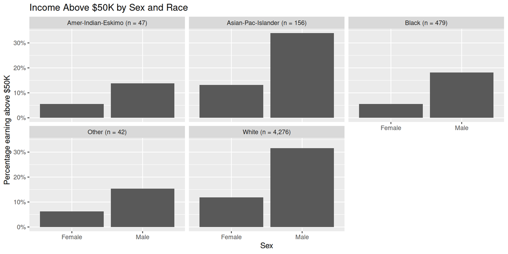

Figure 1: Each panel compares the percentage of female and male adults earning above $50,000 within a race group.

## What it shows, and its limits

- Male adults had a higher percentage earning above $50,000 in every race group.
- The smallest groups were Other (n = 42) and Amer-Indian-Eskimo (n = 47), so their percentages should be interpreted carefully.
- These plots show differences between groups, not the reasons behind those differences.

## Why it matters

These differences raise questions about how education, occupation, and working hours may be related to income. Exploring these factors could help explain patterns that this comparison alone cannot answer.

## Question: WTA Sports dataset

How does the percentage of WTA Grand Slam matches lasting over 120 minutes differ across court surfaces and years?

## Data: WTA Grand Slam matches

The WTA Grand Slam dataset comes from the SCORE Sports Data Repository and contains women’s tennis match records from 2018 to 2022. Each row represents one match. The dataset includes information about match duration, winner ranking, court surface, and tournament date.

The dataset contains 2,413 match records.

## Hard courts had the highest percentage of long matches in three of five years

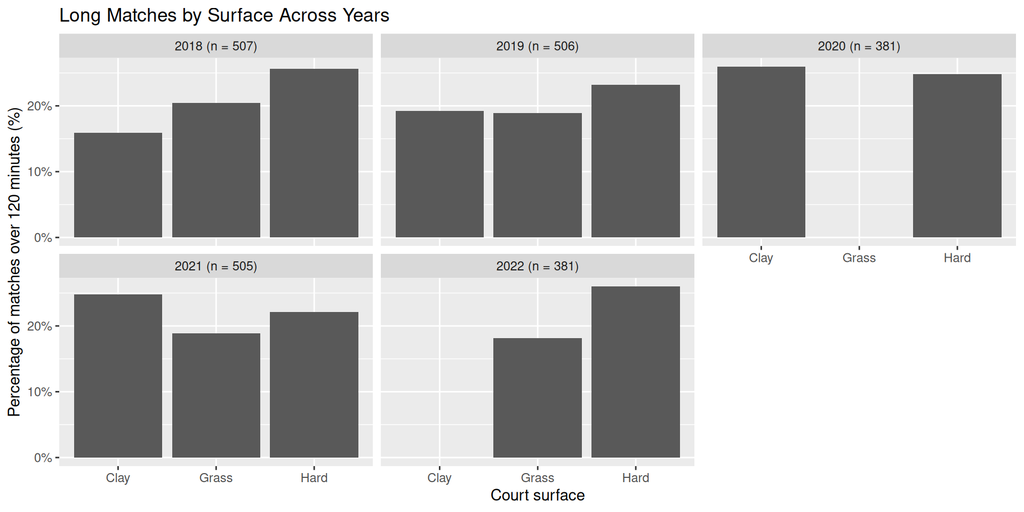

Figure 2: Each panel compares the percentage of long matches across court surfaces in one year.

## What the Sports data shows, and its limits

- The percentage of long matches differed across court surfaces and years.
- Hard courts had the highest percentage in 2018, 2019, and 2022, while Clay had the highest in 2020 and 2021.
- 133 match-duration values were missing, so not every match could be classified.
- These results show differences between groups, not the reasons behind those differences.

## Why it matters

These patterns raise further questions about why match duration varies across surfaces and years. Player matchups and tournament conditions could be interesting factors to explore in a future analysis.

## Sources and AI use

- Becker, B., & Kohavi, R. (1996). Adult [Data set]. UCI Machine Learning Repository. https://doi.org/10.24432/C5XW20
- Fairlearn. (n.d.). Adult Census dataset. https://fairlearn.org/v0.15/user_guide/datasets/adult_data.html
- Yurko, R. (2023, May 24). WTA Grand Slam matches. SCORE Sports Data Repository. https://data.scorenetwork.org/tennis/wta-grand-slam-matches.html
- “AI use: I used ChatGPT to understand R code.”